# Distribuições de probabilidade, hipótese nula e valor p

Paulo S. P Silveira (paulo.silveira@fm.usp.br) Koichi Sameshima (koichi.sameshima@fm.usp.br) José O. Siqueira (jose.siqueira@fm.usp.br)

# Objetivos desta aula

Ao final desta aula o aluno deve ser capaz de:

- definir distribuição de probabilidades;
- definir e aplicar a distribuição Binomial;
- definir hipóteses estatísticas (hipótese nula e alternativa);
- diferenciar erros do tipo I e II (alfa e beta);
- interpretar o valor-p;

## Distribuição Binomial

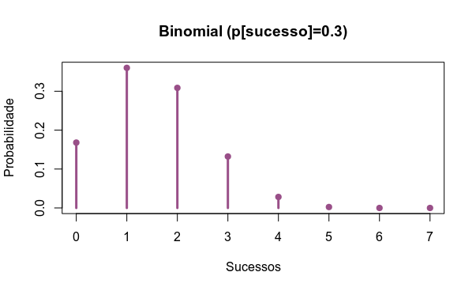

## Distribuição de Poisson

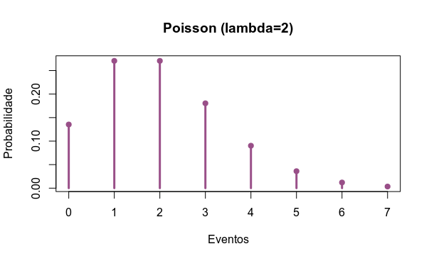

## Distribuição normal

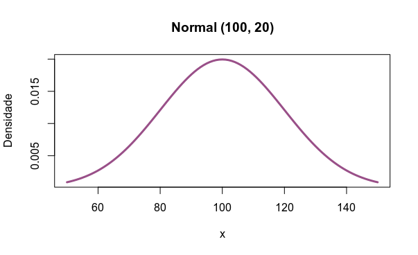

## Continuando a deformação

[figure not shown]

# Exemplo hipotético

Suponha que foi feito um levantamento sobre o número de drogas em uso por gestantes .

```r
DrgGrv <- read.table("Drogas_Gravidez.txt", header=TRUE, sep="\t")
print(DrgGrv)
```

[output not shown]

O arquivo *Drogas_Gravidez.txt* tem duas colunas:

- a primeira linha tem os nomes das variáveis (header=TRUE),
- as colunas estão separadas por *tab* (sep=“\t”)

A variável **DrgGrv** é um *data frame*:

```r
is.data.frame(DrgGrv)
```

[output not shown]

## Gráfico (contagens)

```r
plot (DrgGrv)
```

[output not shown]

### No estilo *histogram-like (vertical lines)*

```r
plot (DrgGrv,type="h")
```

[output not shown]

Como foi que eu descobri isto? [Quick-R: Line charts](https://www.statmethods.net/graphs/line.html)

### Para manter as bolinhas

```r
plot (DrgGrv,type="h")
points(DrgGrv)
```

[output not shown]

### Colorir

Encontrei mais em [Quick-R: Graphical Parameters](https://www.statmethods.net/advgraphs/parameters.html)

```r
plot (DrgGrv,type="h", col="#994F88", lwd=3)
points(DrgGrv, pch=21, col="#994F88", bg="#994F88")
```

[output not shown]

### Cores amigáveis para daltônicos:

```r
source("friendlycolor.R")
plot (DrgGrv,type="h", col=friendlycolor(8), lwd=3)
points(DrgGrv, pch=21, col=friendlycolor(8), bg=friendlycolor(12))
```

[output not shown]

#### friendlydemo.R

Exibindo todas as cores da função friendlycolor():

```r
# friendlydemo.R
# exibe as 46 cores disponíveis em friendlycolor.R
source("friendlycolor.R")
indice <- 1 # primeiro indice
# plota um gráfico vazio
plot(NA, xlim=c(0,9), ylim=c(0,7),
     xlab=NA, ylab=NA, axes = FALSE)
for (x in 1:8)
{
  for (y in 1:6)
  {
    # pula se acabaram as cores
    if (indice > 46) {next}
    points ( x, 7-y,
             pch=21, cex=5,
             col="black",
             bg=friendlycolor(indice)
           )

    cortexto <- "black"

    if (
        (indice >= 25 & indice <= 27)
        |
        (indice >= 31 & indice <= 36)
       )
    {
      cortexto <- "white"
    }
    text(x, 7-y, indice, col=cortexto)
    # incrementa (proxima cor)
    indice <- indice+1
  }
}
```

[output not shown]

## Distribuição de probabilidades

```r
DrgGrv <- read.table("Drogas_Gravidez.txt", header=TRUE, sep="\t")
print(DrgGrv)
names(DrgGrv)
DrgGrv$Porcentagem <- round(DrgGrv$Pacientes/sum(DrgGrv$Pacientes)*100,2)
names(DrgGrv)
print(DrgGrv)
```

[output not shown]

### Características

- a coluna “Porcentagem” soma 1 ou 100%
- todos os valores são positivos
- todos os valores ficam entre 0 e 1 (ou entre 0% e 100%)

```r
sum(DrgGrv$Porcentagem)
```

[output not shown]

```r
DrgGrv$Porcentagem < 0
```

[output not shown]

```r
sum(DrgGrv$Porcentagem < 0)
```

[output not shown]

```r
DrgGrv$Porcentagem >= 0 & DrgGrv$Porcentagem <= 100
```

[output not shown]

```r
sum (DrgGrv$Porcentagem >= 0 & DrgGrv$Porcentagem <= 100)
```

[output not shown]

## Gráfico em porcentagem

Como *DrgGrv* agora tem três colunas, precisamos indicar quais colunas quero usar como $x$ (**DrgGrv$Drogas**) e $y$ (**DrgGrv$Porcentagem**)

```r
source("friendlycolor.R")
plot (DrgGrv$Drogas, DrgGrv$Porcentagem,
      type="h", col=friendlycolor(20), lwd=3)
points(DrgGrv$Drogas, DrgGrv$Porcentagem,
       pch=21,
       col=friendlycolor(20), bg=friendlycolor(23))
```

[output not shown]

### Corrigindo os eixos

```r
source("friendlycolor.R")
plot (DrgGrv$Drogas, DrgGrv$Porcentagem,
      type="h", col=friendlycolor(20), lwd=3,
      xlab="Número de drogas utilizadas",
      ylab="Porcentagem de gestantes")
points(DrgGrv$Drogas, DrgGrv$Porcentagem,
       pch=21,
       col=friendlycolor(20), bg=friendlycolor(23))
```

[output not shown]

### *Density plots*

O número de drogas utilizadas é uma variável quantitativa discreta.

Apenas para demonstrar (não é a forma apropriada), caso a variável fosse quantitativa contínua, poderíamos usar um *density plot*

Primeiro criamos uma variável para conter a densidade de probabilidades

```r
# desdobra a quantidade de pacientes
populacao <- c() # cria um vetor vazio
for (r in 1:nrow(DrgGrv))
{
  # acumula no vetor o número de drogas
  populacao <- c(populacao, rep(DrgGrv$Drogas, times=DrgGrv$Pacientes))
}
# usa a funcao R que transforma em densidade de probabilidade
densidade <- density(populacao)
```

```r
source("friendlycolor.R")
plot (densidade,
      col=friendlycolor(20), lwd=3,
      xlab="Número de drogas utilizadas",
      ylab="Porcentagem de gestantes")
```

[output not shown]

#### Dando nome ao gráfico

A função *plot()* tem muitos parâmetros; aqui usamos o parâmetro *main*.

```r
source("friendlycolor.R")
# note o titulo em duas linhas usando-se \\n
plot (densidade,
      main = "Distribuição do uso de\ndrogas em gestantes",
      col=friendlycolor(20), lwd=3,
      xlab="Número de drogas utilizadas",
      ylab="Porcentagem de gestantes")
```

[output not shown]

## gestantes.R

Tudo o que foi feito até agora pode ser colocado em um único *Rscript*

```r
# gestantes.R
#   le os dados e cria os graficos

source("friendlycolor.R")

# le os dados
DrgGrv <- read.table("Drogas_Gravidez.txt",
                     header=TRUE, sep="\t")

# cria coluna para a porcentagem
DrgGrv$Porcentagem <- round(DrgGrv$Pacientes/
                            sum(DrgGrv$Pacientes)*100,2)

# exibe a tabela de dados
cat("Utilização de drogas em gestantes\n")
print(DrgGrv)

# exibe o grafico no estilo 'histograma'
# (variavel quantitativa discreta)
plot (DrgGrv$Drogas, DrgGrv$Porcentagem,
      main = "Distribuição do uso de\ndrogas em gestantes",
      type="h", col=friendlycolor(20), lwd=3,
      xlab="Número de drogas utilizadas",
      ylab="Porcentagem de gestantes")
points(DrgGrv$Drogas, DrgGrv$Porcentagem,
       pch=21,
       col=friendlycolor(20), bg=friendlycolor(23))

# tratando a variavel como quantitativa continua
# (apenas por exemplo; nao eh apropriado fazer isto)
# cria uma populacao com as quantidades
# de drogas utilizadas pelas pacientes
populacao <- c() # cria um vetor vazio
for (r in 1:nrow(DrgGrv))
{
  # acumula no vetor o número de drogas
  populacao <- c(populacao,
                 rep(DrgGrv$Drogas, times=DrgGrv$Pacientes))
}
# usa a funcao R que transforma
# em densidade de probabilidade
densidade <- density(populacao)
# exibe o grafico no estilo 'density plot'
plot (densidade,
      main = "Distribuição do uso de\ndrogas em gestantes",
      col=friendlycolor(20), lwd=3,
      xlab="Número de drogas utilizadas",
      ylab="Porcentagem de gestantes")
```

[output not shown]